# Chapter 6: Analysis of longitudinal data

## Chapter 8 of MABS using the RATS

Read in the data (from the RDS object that retains the factor type definition):

```r
library(data.table)
library(ggplot2)
library(dplyr)
library(magrittr)
RATSL<-readRDS("data/RATSL.rds")
```

### Glimpse the data

```r
glimpse(RATSL)
```

```
## Observations: 176
## Variables: 5
## $ ID     <fct> 1, 2, 3, 4, 5, 6, 7, 8, 9, 10, 11, 12, 13, 14, 15, 16, ...
## $ Group  <fct> 1, 1, 1, 1, 1, 1, 1, 1, 2, 2, 2, 2, 3, 3, 3, 3, 1, 1, 1...
## $ COL    <fct> WD1, WD1, WD1, WD1, WD1, WD1, WD1, WD1, WD1, WD1, WD1, ...
## $ Weight <int> 240, 225, 245, 260, 255, 260, 275, 245, 410, 405, 445, ...
## $ Time   <int> 1, 1, 1, 1, 1, 1, 1, 1, 1, 1, 1, 1, 1, 1, 1, 1, 8, 8, 8...
```

```r
head(RATSL)
```

```
##    ID Group COL Weight Time
## 1:  1     1 WD1    240    1
## 2:  2     1 WD1    225    1
## 3:  3     1 WD1    245    1
## 4:  4     1 WD1    260    1
## 5:  5     1 WD1    255    1
## 6:  6     1 WD1    260    1
```

```r
tail(RATSL)
```

```
##    ID Group  COL Weight Time
## 1: 11     2 WD64    472   64
## 2: 12     2 WD64    628   64
## 3: 13     3 WD64    525   64
## 4: 14     3 WD64    559   64
## 5: 15     3 WD64    548   64
## 6: 16     3 WD64    569   64
```

So we have rats with multiple observations and each one belongs to a one of three treatment groups. Next let’s plot weight of each rat in each groups separately as a time series:

### Plot groups separately

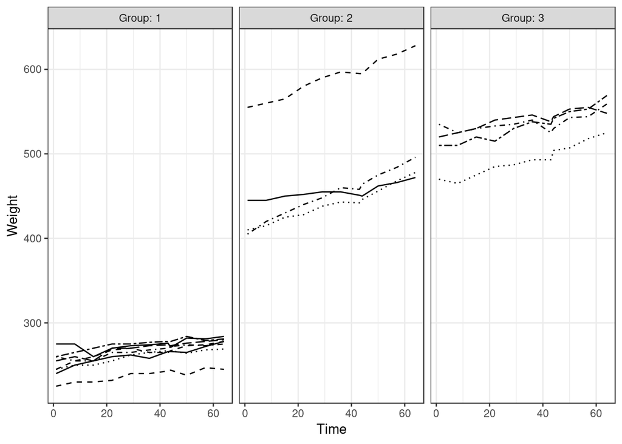

```r
p1 <- ggplot(RATSL, aes(x = Time, y = Weight, linetype = ID))
p2 <- p1 + geom_line() + scale_linetype_manual(values = rep(1:10, times=4))
p3 <- p2 + facet_grid(. ~ Group, labeller = label_both)
p4 <- p3 + theme_bw() + theme(legend.position = "none")
p5 <- p4 + theme(panel.grid.minor.y = element_blank())
p6 <- p5 + scale_y_continuous(limits = c(min(RATSL$Weight), max(RATSL$Weight)))
p6
```

We can already see that there is a increasing trend in all groups and already a significant baseline differencies among groups.

### Standardise the scores and replot

```r
RATSL <- RATSL %>%
   group_by(Time) %>%
   mutate( stdweight = (Weight - mean(Weight))/sd(Weight) ) %>%
   ungroup()
glimpse(RATSL)
```

```
## Observations: 176
## Variables: 6
## $ ID        <fct> 1, 2, 3, 4, 5, 6, 7, 8, 9, 10, 11, 12, 13, 14, 15, 1...
## $ Group     <fct> 1, 1, 1, 1, 1, 1, 1, 1, 2, 2, 2, 2, 3, 3, 3, 3, 1, 1...
## $ COL       <fct> WD1, WD1, WD1, WD1, WD1, WD1, WD1, WD1, WD1, WD1, WD...
## $ Weight    <int> 240, 225, 245, 260, 255, 260, 275, 245, 410, 405, 44...
## $ Time      <int> 1, 1, 1, 1, 1, 1, 1, 1, 1, 1, 1, 1, 1, 1, 1, 1, 8, 8...
## $ stdweight <dbl> -1.0011429, -1.1203857, -0.9613953, -0.8421525, -0.8...
```

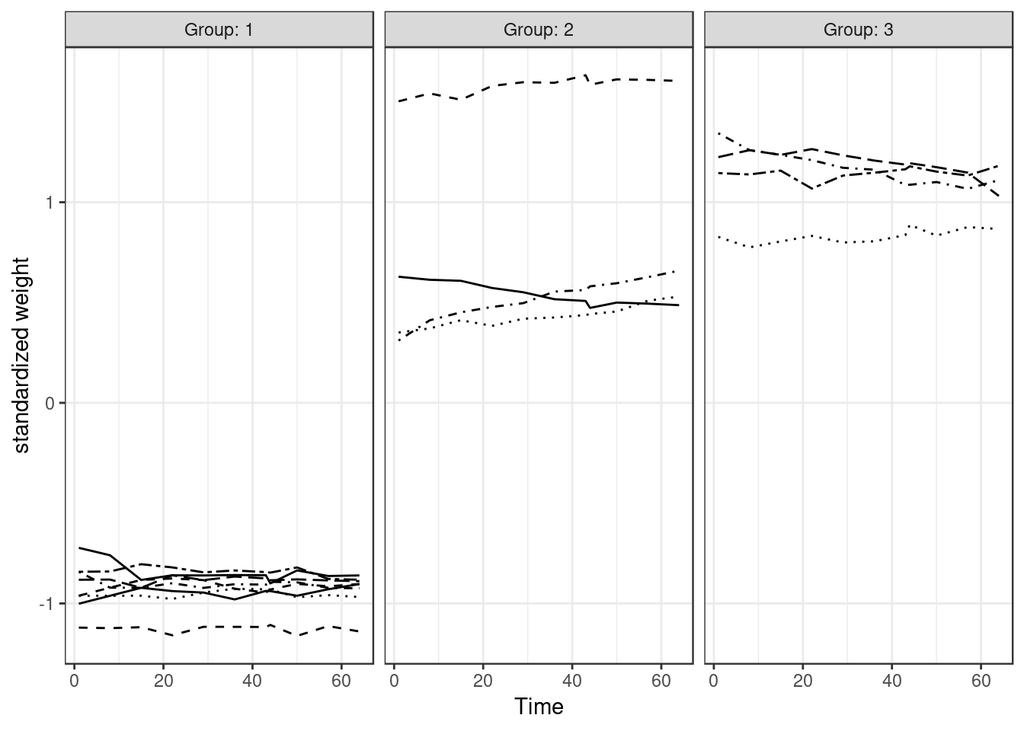

```r
p1 <- ggplot(RATSL, aes(x = Time, y = stdweight, linetype = ID))
p2 <- p1 + geom_line() + scale_linetype_manual(values = rep(1:10, times=4))
p3 <- p2 + facet_grid(. ~ Group, labeller = label_both)
p4 <- p3 + theme_bw() + theme(legend.position = "none")
p5 <- p4 + theme(panel.grid.minor.y = element_blank())
p6 <- p5 + scale_y_continuous(name = "standardized weight")
p6
```

After standardizing, we can see some differences in trends: Group 1 seems to be quite steady, group 2 mostly increasing weigth (with one exception) and group 3 generally has a decreasing trend.

### Number of weeks, baseline (week 0) included:

```r
n <- RATSL$Time %>% unique() %>% length()
# Make a summary data:
RATSS <- RATSL %>%
   group_by(Group, Time) %>%
   summarise( mean=mean(Weight), se=sd(Weight)/sqrt(n) ) %>%
   ungroup()
glimpse(RATSS)
```

```
## Observations: 33
## Variables: 4
## $ Group <fct> 1, 1, 1, 1, 1, 1, 1, 1, 1, 1, 1, 2, 2, 2, 2, 2, 2, 2, 2,...
## $ Time  <int> 1, 8, 15, 22, 29, 36, 43, 44, 50, 57, 64, 1, 8, 15, 22, ...
## $ mean  <dbl> 250.625, 255.000, 254.375, 261.875, 264.625, 265.000, 26...
## $ se    <dbl> 4.589478, 3.947710, 3.460116, 4.100800, 3.333956, 3.5529...
```

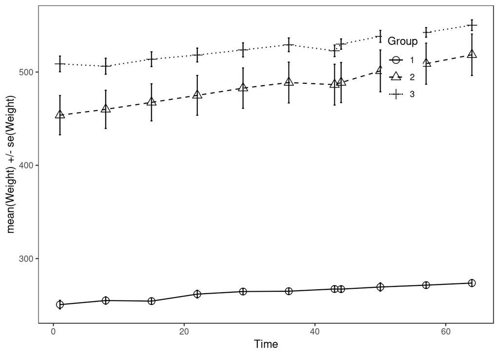

```r
p1 <- ggplot(RATSS, aes(x = Time, y = mean, linetype = Group, shape = Group))
p2 <- p1 + geom_line() + scale_linetype_manual(values = c(1,2,3))
p3 <- p2 + geom_point(size=3) + scale_shape_manual(values = c(1,2,3))
p4 <- p3 + geom_errorbar(aes(ymin=mean-se, ymax=mean+se, linetype="1"), width=0.3)
p5 <- p4 + theme_bw() + theme(panel.grid.major = element_blank(), panel.grid.minor = element_blank())
p6 <- p5 + theme(legend.position = c(0.8,0.8))
p7 <- p6 + scale_y_continuous(name = "mean(Weight) +/- se(Weight)")
p7
```

Groups have clear baseline differences. We can also see that variation inside groups is different (group 1 have very similar weights, group 2 has largest in-group differences). Generally all groups show increasing trend, group 2 maybe highest.

### Boxplot to spot incosistent distributions

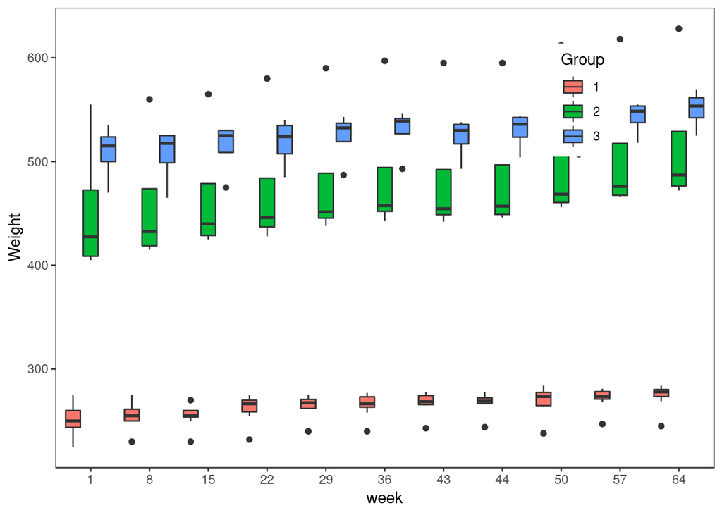

```r
p1 <- ggplot(RATSL, aes(x = factor(Time), y = Weight, fill = Group))
p2 <- p1 + geom_boxplot(position = position_dodge(width = 0.9))
p3 <- p2 + theme_bw() + theme(panel.grid.major = element_blank(), panel.grid.minor = element_blank())
p4 <- p3 + theme(legend.position = c(0.8,0.8))
p5 <- p4 + scale_x_discrete(name = "week")
# Black & White version:
#p6 <- p5 + scale_fill_grey(start = 0.5, end = 1)
p5
```

We can see that group 2 actually seems to have one outlier that causes mean to go higher than maybe reasonable. Also group 1 has one outlier that drags mean downwards. If we compare trends of group medians (that is more robust to utliers), they show quite similar increasing slopes.

### Group differences and boxplots

```r
# Make a summary data of the post treatment weeks (1-8)
RATSG <- RATSL %>%
   filter(Time > 0) %>%
   group_by(Group, ID) %>%
   summarise( mean=mean(Weight) ) %>%
   ungroup()
glimpse(RATSG)
```

```
## Observations: 16
## Variables: 3
## $ Group <fct> 1, 1, 1, 1, 1, 1, 1, 1, 2, 2, 2, 2, 3, 3, 3, 3
## $ ID    <fct> 1, 2, 3, 4, 5, 6, 7, 8, 9, 10, 11, 12, 13, 14, 15, 16
## $ mean  <dbl> 261.0909, 237.6364, 260.1818, 266.5455, 269.4545, 274.72...
```

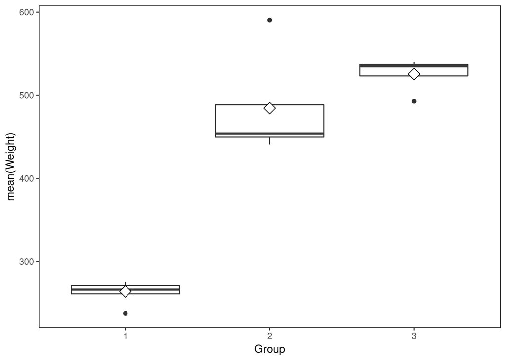

```r
p1 <- ggplot(RATSG, aes(x = Group, y = mean))
p2 <- p1 + geom_boxplot()
p3 <- p2 + theme_bw() + theme(panel.grid.major = element_blank(), panel.grid.minor = element_blank())
p4 <- p3 + stat_summary(fun.y = "mean", geom = "point", shape=23, size=4, fill = "white")
p5 <- p4 + scale_y_continuous(name = "mean(Weight)")
p5
```

Same outliers that we identified earlier show up here also. We also now find one outlier in group 3, that earlier could have been considered as an borderline case (appearing only on three weeks)

### Remove outliers

```r
RATSG1 <- RATSG %>%
   filter( (Group == 1 & mean > 240) |
             (Group == 2 & mean < 500)  |
             (Group == 3 & mean > 500))
glimpse(RATSG1)
```

```
## Observations: 13
## Variables: 3
## $ Group <fct> 1, 1, 1, 1, 1, 1, 1, 2, 2, 2, 3, 3, 3
## $ ID    <fct> 1, 3, 4, 5, 6, 7, 8, 9, 10, 11, 14, 15, 16
## $ mean  <dbl> 261.0909, 260.1818, 266.5455, 269.4545, 274.7273, 274.63...
```

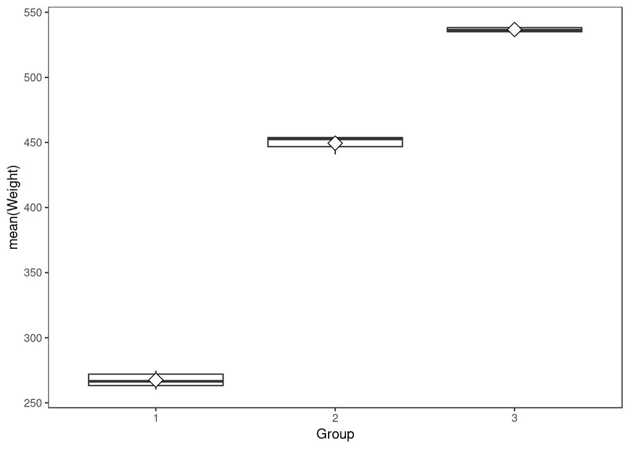

```r
p1 <- ggplot(RATSG1, aes(x = Group, y = mean))
p2 <- p1 + geom_boxplot()
p3 <- p2 + theme_bw() + theme(panel.grid.major = element_blank(), panel.grid.minor = element_blank())
p4 <- p3 + stat_summary(fun.y = "mean", geom = "point", shape=23, size=4, fill = "white")
p5 <- p4 + scale_y_continuous(name = "mean(Weight)")
p5
```

Now that outliers are removed, variances inside groups look much better.

### ANOVA without outliers

Without the outliers, let’s apply one-way analysis of variance (ANOVA is a generalization of t-test. T-test works only with only in case of two groups)

```r
summary(aov(mean ~ Group, data = RATSG1))
```

```
##             Df Sum Sq Mean Sq F value   Pr(>F)
## Group        2 175958   87979    2577 2.72e-14 ***
## Residuals   10    341      34
## ---
## Signif. codes:  0 '***' 0.001 '**' 0.01 '*' 0.05 '.' 0.1 ' ' 1
```

We see highly statistically highly significant difference among groups (p=2.7e-14) which was anticipated from the earlier plots already.

### Include baseline

Next, add the baseline from the original data as a new variable to the summary data, and then remove outliers again.

```r
RATS<-fread("https://raw.githubusercontent.com/KimmoVehkalahti/MABS/master/Examples/data/rats.txt")[,-1,with=F] # RATS has row numbers, remove them
baseline <- RATS$WD1
RATSG2 <- RATSG %>% mutate(baseline) %>%
   filter( (Group == 1 & mean > 240) |
             (Group == 2 & mean < 500)  |
             (Group == 3 & mean > 500))
```

### Fit the ANCOVA model and see the results

```r
fit <- lm(mean ~ baseline + Group, data = RATSG2)
summary(fit)
```

```
##
## Call:
## lm(formula = mean ~ baseline + Group, data = RATSG2)
##
## Residuals:
##     Min      1Q  Median      3Q     Max
## -6.0310 -2.6287  0.1002  1.8269  7.1808
##
## Coefficients:
##             Estimate Std. Error t value Pr(>|t|)
## (Intercept) 201.1903    25.7382   7.817 2.66e-05 ***
## baseline      0.2605     0.1010   2.580   0.0297 *
## Group2      138.8380    17.0411   8.147 1.91e-05 ***
## Group3      199.6530    27.1916   7.342 4.36e-05 ***
## ---
## Signif. codes:  0 '***' 0.001 '**' 0.01 '*' 0.05 '.' 0.1 ' ' 1
##
## Residual standard error: 4.669 on 9 degrees of freedom
## Multiple R-squared:  0.9989, Adjusted R-squared:  0.9985
## F-statistic:  2692 on 3 and 9 DF,  p-value: 1.324e-13
```

Including baseline as covariate, we can see statistical significance among all three groups, but it’s not as huge as without baseline.

## Chapter 9 of MABS using the BPRS

Read in the data (from the RDS object that retains the factor type definition):

```r
BPRSL<-readRDS("data/BPRSL.rds")
glimpse(BPRSL)
```

```
## Observations: 360
## Variables: 5
## $ treatment <fct> 1, 1, 1, 1, 1, 1, 1, 1, 1, 1, 1, 1, 1, 1, 1, 1, 1, 1...
## $ subject   <fct> 1, 2, 3, 4, 5, 6, 7, 8, 9, 10, 11, 12, 13, 14, 15, 1...
## $ COL       <fct> week0, week0, week0, week0, week0, week0, week0, wee...
## $ bprs      <int> 42, 58, 54, 55, 72, 48, 71, 30, 41, 57, 30, 55, 36, ...
## $ Week      <int> 0, 0, 0, 0, 0, 0, 0, 0, 0, 0, 0, 0, 0, 0, 0, 0, 0, 0...
```

### Plot

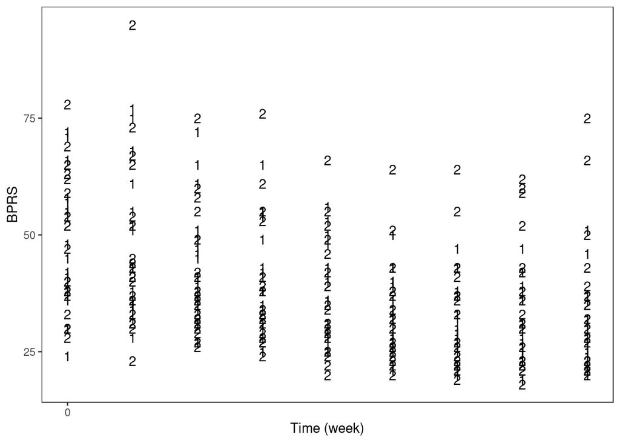

```r
p1 <- ggplot(BPRSL, aes(x = Week, y = bprs, group = subject))
p2 <- p1 + geom_text(aes(label = treatment))
p3 <- p2 + scale_x_continuous(name = "Time (week)", breaks = seq(0, 60, 10))
p4 <- p3 + scale_y_continuous(name = "BPRS")
p5 <- p4 + theme_bw()
p6 <- p5 + theme(panel.grid.major = element_blank(), panel.grid.minor = element_blank())
p6
```

Hard to make any conclusions, but general trend seems to be declining and slightly increasing at the end. This could indicate that we would need non-linear model to fit the data best, but let’s first proceed with linear models.

### Regression

```r
BPRS_reg <- lm(bprs ~ Week + treatment, data = BPRSL)
summary(BPRS_reg)
```

```
##
## Call:
## lm(formula = bprs ~ Week + treatment, data = BPRSL)
##
## Residuals:
##     Min      1Q  Median      3Q     Max
## -22.454  -8.965  -3.196   7.002  50.244
##
## Coefficients:
##             Estimate Std. Error t value Pr(>|t|)
## (Intercept)  46.4539     1.3670  33.982   <2e-16 ***
## Week         -2.2704     0.2524  -8.995   <2e-16 ***
## treatment2    0.5722     1.3034   0.439    0.661
## ---
## Signif. codes:  0 '***' 0.001 '**' 0.01 '*' 0.05 '.' 0.1 ' ' 1
##
## Residual standard error: 12.37 on 357 degrees of freedom
## Multiple R-squared:  0.1851, Adjusted R-squared:  0.1806
## F-statistic: 40.55 on 2 and 357 DF,  p-value: < 2.2e-16
```

There is a statistically significant trend in time, but treatment doesn’t seem to associate.

### Plot

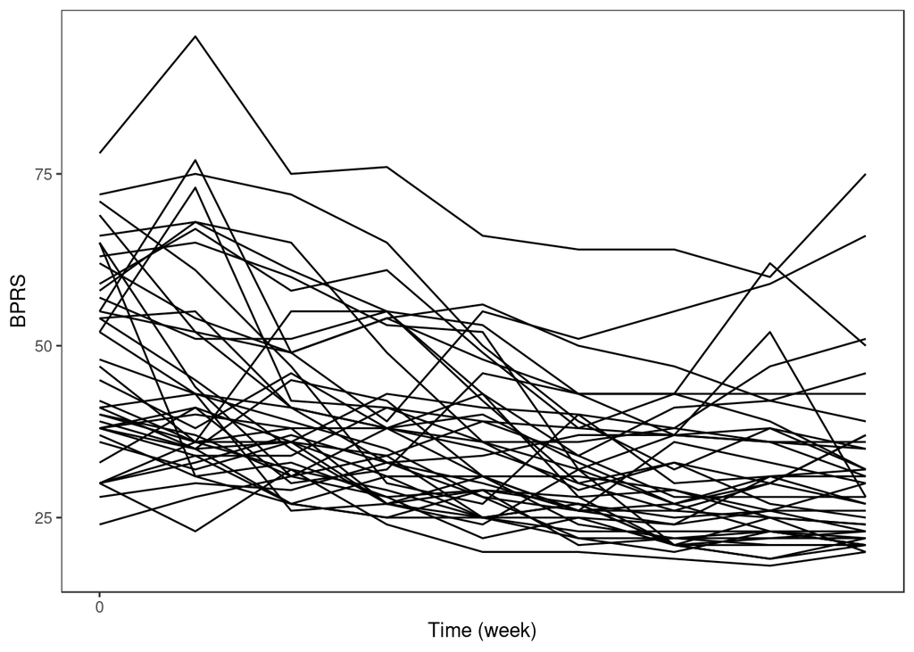

```r
p1 <- ggplot(BPRSL[order(Week)], aes(x = Week, y = bprs, group = interaction(subject, treatment)))
p2 <- p1 + geom_line() # + geom_line(aes(linetype = treatment)) # treatment given in middle
p3 <- p2 + scale_x_continuous(name = "Time (week)", breaks = seq(0, 60, 10))
p4 <- p3 + scale_y_continuous(name = "BPRS")
p5 <- p4 + theme_bw() + theme(legend.position = "top")
p6 <- p5 + theme(panel.grid.major = element_blank(), panel.grid.minor = element_blank())
p6
```

Line plot confirms this association with time, as well as pair plots below.

### Pairs plot

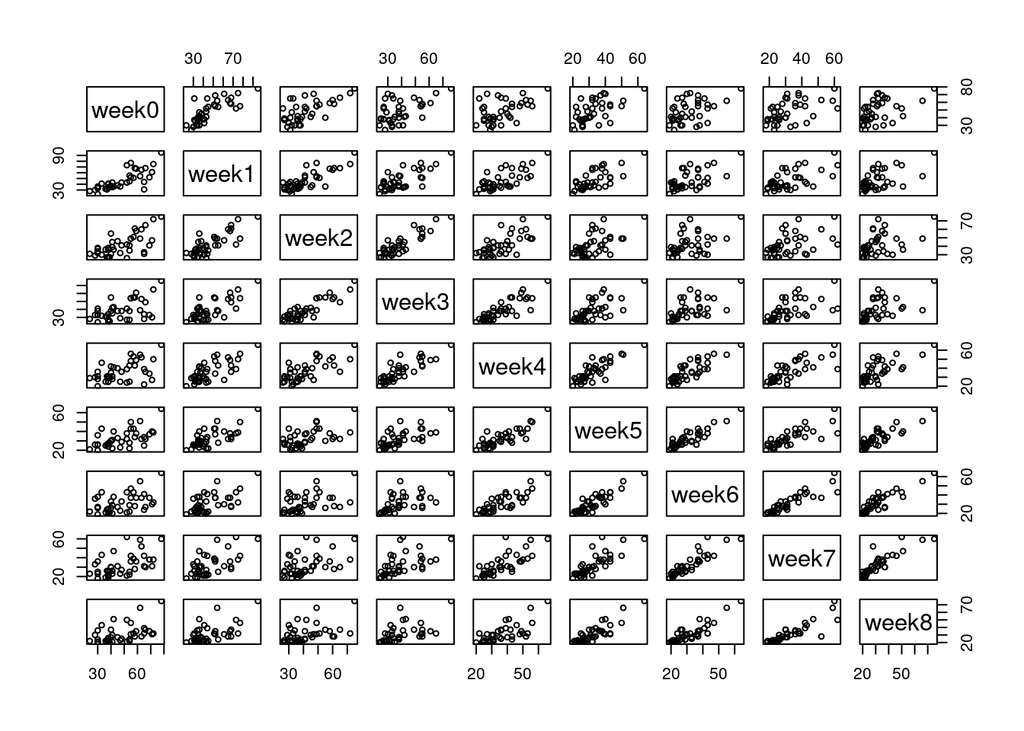

```r
BPRS<-fread("https://raw.githubusercontent.com/KimmoVehkalahti/MABS/master/Examples/data/BPRS.txt")
pairs(BPRS[, 3:11], cex = 0.7)
```

### LMM, random intercept

Let’s analyze data now with linear mixed model and three different model definitions: random intercept, random slope and intercept, and random slope and random intercept including their interaction term.

```r
library(lme4)
BPRS_ref <- lmer(bprs ~ Week + treatment + (1 | subject), data = BPRSL, REML = FALSE)
summary(BPRS_ref)
```

```
## Linear mixed model fit by maximum likelihood  ['lmerMod']
## Formula: bprs ~ Week + treatment + (1 | subject)
##    Data: BPRSL
##
##      AIC      BIC   logLik deviance df.resid
##   2748.7   2768.1  -1369.4   2738.7      355
##
## Scaled residuals:
##     Min      1Q  Median      3Q     Max
## -3.0481 -0.6749 -0.1361  0.4813  3.4855
##
## Random effects:
##  Groups   Name        Variance Std.Dev.
##  subject  (Intercept)  47.41    6.885
##  Residual             104.21   10.208
## Number of obs: 360, groups:  subject, 20
##
## Fixed effects:
##             Estimate Std. Error t value
## (Intercept)  46.4539     1.9090  24.334
## Week         -2.2704     0.2084 -10.896
## treatment2    0.5722     1.0761   0.532
##
## Correlation of Fixed Effects:
##            (Intr) Week
## Week       -0.437
## treatment2 -0.282  0.000
```

### LMM, random slope and intercept

```r
BPRS_ref1 <- lmer(bprs ~ Week + treatment + (Week | subject), data = BPRSL, REML = FALSE)
summary(BPRS_ref1)
```

```
## Linear mixed model fit by maximum likelihood  ['lmerMod']
## Formula: bprs ~ Week + treatment + (Week | subject)
##    Data: BPRSL
##
##      AIC      BIC   logLik deviance df.resid
##   2745.4   2772.6  -1365.7   2731.4      353
##
## Scaled residuals:
##     Min      1Q  Median      3Q     Max
## -2.8919 -0.6194 -0.0691  0.5531  3.7976
##
## Random effects:
##  Groups   Name        Variance Std.Dev. Corr
##  subject  (Intercept) 64.8202  8.0511
##           Week         0.9608  0.9802   -0.51
##  Residual             97.4307  9.8707
## Number of obs: 360, groups:  subject, 20
##
## Fixed effects:
##             Estimate Std. Error t value
## (Intercept)  46.4539     2.1052  22.066
## Week         -2.2704     0.2977  -7.626
## treatment2    0.5722     1.0405   0.550
##
## Correlation of Fixed Effects:
##            (Intr) Week
## Week       -0.582
## treatment2 -0.247  0.000
```

```r
anova(BPRS_ref, BPRS_ref1)
```

```
## Data: BPRSL
## Models:
## BPRS_ref: bprs ~ Week + treatment + (1 | subject)
## BPRS_ref1: bprs ~ Week + treatment + (Week | subject)
##           Df    AIC    BIC  logLik deviance  Chisq Chi Df Pr(>Chisq)
## BPRS_ref   5 2748.7 2768.1 -1369.4   2738.7
## BPRS_ref1  7 2745.4 2772.6 -1365.7   2731.4 7.2721      2    0.02636 *
## ---
## Signif. codes:  0 '***' 0.001 '**' 0.01 '*' 0.05 '.' 0.1 ' ' 1
```

Adding slope terms seems to make the model somewhat better (p=0.03).

### LMM, random slope and intercept, intercation term

```r
BPRS_ref2 <- lmer(bprs ~ Week * treatment + (Week | subject), data = BPRSL, REML = FALSE)
summary(BPRS_ref2)
```

```
## Linear mixed model fit by maximum likelihood  ['lmerMod']
## Formula: bprs ~ Week * treatment + (Week | subject)
##    Data: BPRSL
##
##      AIC      BIC   logLik deviance df.resid
##   2744.3   2775.4  -1364.1   2728.3      352
##
## Scaled residuals:
##     Min      1Q  Median      3Q     Max
## -3.0512 -0.6271 -0.0767  0.5288  3.9260
##
## Random effects:
##  Groups   Name        Variance Std.Dev. Corr
##  subject  (Intercept) 65.0016  8.0624
##           Week         0.9688  0.9843   -0.51
##  Residual             96.4699  9.8219
## Number of obs: 360, groups:  subject, 20
##
## Fixed effects:
##                 Estimate Std. Error t value
## (Intercept)      47.8856     2.2522  21.262
## Week             -2.6283     0.3589  -7.323
## treatment2       -2.2911     1.9090  -1.200
## Week:treatment2   0.7158     0.4010   1.785
##
## Correlation of Fixed Effects:
##             (Intr) Week   trtmn2
## Week        -0.650
## treatment2  -0.424  0.469
## Wek:trtmnt2  0.356 -0.559 -0.840
```

```r
anova(BPRS_ref1, BPRS_ref2)
```

```
## Data: BPRSL
## Models:
## BPRS_ref1: bprs ~ Week + treatment + (Week | subject)
## BPRS_ref2: bprs ~ Week * treatment + (Week | subject)
##           Df    AIC    BIC  logLik deviance  Chisq Chi Df Pr(>Chisq)
## BPRS_ref1  7 2745.4 2772.6 -1365.7   2731.4
## BPRS_ref2  8 2744.3 2775.4 -1364.1   2728.3 3.1712      1    0.07495 .
## ---
## Signif. codes:  0 '***' 0.001 '**' 0.01 '*' 0.05 '.' 0.1 ' ' 1
```

Adding interaction doesn’t seem to be so important (p=0.07) but probably doesn’t hurt either.

### Plot fitted values from models

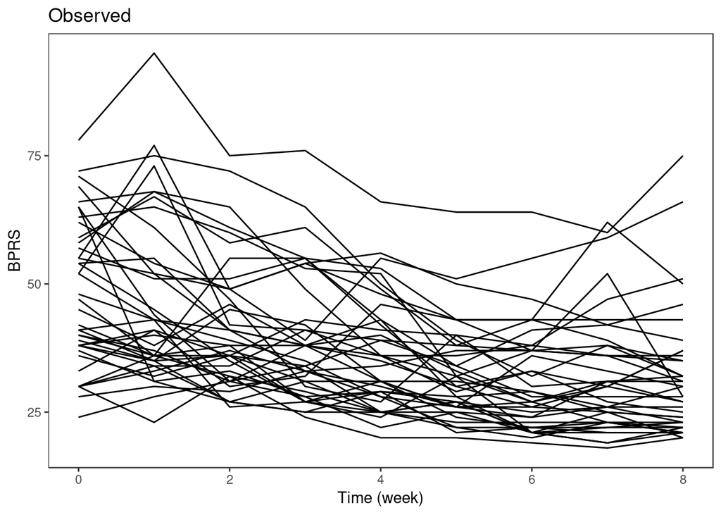

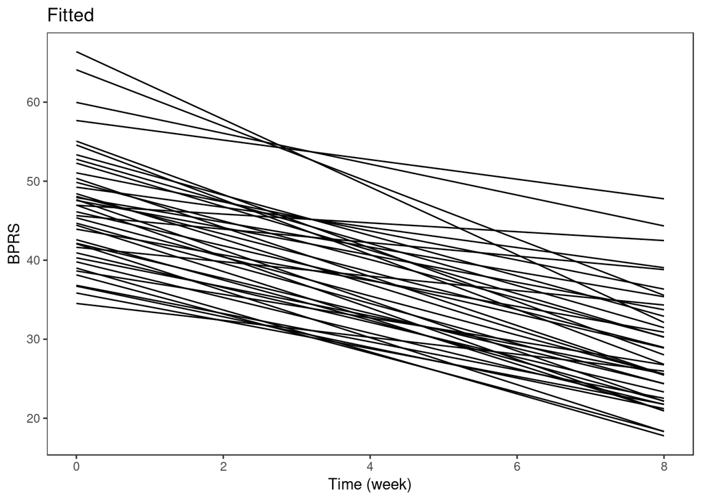

```r
Fitted <- fitted(BPRS_ref2)
BPRSL1 <- BPRSL %>% mutate(Fitted)
p1 <- ggplot(BPRSL1, aes(x = Week, y = bprs, group = interaction(subject, treatment)))
p2 <- p1 + geom_line() #+ geom_line(aes(linetype = Group))
p3 <- p2 + scale_x_continuous(name = "Time (week)")
p4 <- p3 + scale_y_continuous(name = "BPRS")
p5 <- p4 + theme_bw() + theme(legend.position = "right") # "none" in the book
p6 <- p5 + theme(panel.grid.major = element_blank(), panel.grid.minor = element_blank())
p7 <- p6 + ggtitle("Observed")
graph1 <- p7

p1 <- ggplot(BPRSL1, aes(x = Week, y = Fitted, group = interaction(subject, treatment)))
p2 <- p1 + geom_line() #+ geom_line(aes(linetype = Group))
p3 <- p2 + scale_x_continuous(name = "Time (week)")
p4 <- p3 + scale_y_continuous(name = "BPRS")
p5 <- p4 + theme_bw() + theme(legend.position = "right")
p6 <- p5 + theme(panel.grid.major = element_blank(), panel.grid.minor = element_blank())
p7 <- p6 + ggtitle("Fitted")
graph2 <- p7

graph1; graph2
```

Fitted values seem to estimate general declining linear trend for all individuals. However, as we noted in the earlier first plot, the relationship is probably actually non-linear, as wee here that it increases at the end after first declining. Thus, depending on application, we might want to include second and third order polynomial term to account for this non-linearity:

```r
BPRS_ref3 <- lmer(bprs ~ poly(Week,3)*treatment + (Week | subject), data = BPRSL, REML = FALSE)
summary(BPRS_ref3)
```

```
## Linear mixed model fit by maximum likelihood  ['lmerMod']
## Formula: bprs ~ poly(Week, 3) * treatment + (Week | subject)
##    Data: BPRSL
##
##      AIC      BIC   logLik deviance df.resid
##   2736.7   2783.4  -1356.4   2712.7      348
##
## Scaled residuals:
##     Min      1Q  Median      3Q     Max
## -3.0468 -0.5958 -0.0857  0.4910  3.9220
##
## Random effects:
##  Groups   Name        Variance Std.Dev. Corr
##  subject  (Intercept) 65.865   8.116
##           Week         1.007   1.003    -0.52
##  Residual             91.897   9.586
## Number of obs: 360, groups:  subject, 20
##
## Fixed effects:
##                            Estimate Std. Error t value
## (Intercept)                 37.3722     1.7074  21.888
## poly(Week, 3)1            -128.7615    17.4536  -7.377
## poly(Week, 3)2              12.4209    13.5571   0.916
## poly(Week, 3)3              25.1360    13.5571   1.854
## treatment2                   0.5722     1.0105   0.566
## poly(Week, 3)1:treatment2   35.0685    19.1726   1.829
## poly(Week, 3)2:treatment2   33.8452    19.1726   1.765
## poly(Week, 3)3:treatment2  -25.1862    19.1726  -1.314
##
## Correlation of Fixed Effects:
##             (Intr) pl(W,3)1 pl(W,3)2 pl(W,3)3 trtmn2 p(W,3)1: p(W,3)2:
## poly(Wk,3)1 -0.017
## poly(Wk,3)2  0.000  0.000
## poly(Wk,3)3  0.000  0.000    0.000
## treatment2  -0.296  0.000    0.000    0.000
## ply(W,3)1:2  0.000 -0.549    0.000    0.000    0.000
## ply(W,3)2:2  0.000  0.000   -0.707    0.000    0.000  0.000
## ply(W,3)3:2  0.000  0.000    0.000   -0.707    0.000  0.000    0.000
```

```r
anova(BPRS_ref2, BPRS_ref3)
```

```
## Data: BPRSL
## Models:
## BPRS_ref2: bprs ~ Week * treatment + (Week | subject)
## BPRS_ref3: bprs ~ poly(Week, 3) * treatment + (Week | subject)
##           Df    AIC    BIC  logLik deviance Chisq Chi Df Pr(>Chisq)
## BPRS_ref2  8 2744.3 2775.4 -1364.1   2728.3
## BPRS_ref3 12 2736.7 2783.4 -1356.4   2712.7 15.54      4   0.003703 **
## ---
## Signif. codes:  0 '***' 0.001 '**' 0.01 '*' 0.05 '.' 0.1 ' ' 1
```

It seems to perform much better on paper. Let’s also plot these fitted values with second and third order polynomial term:

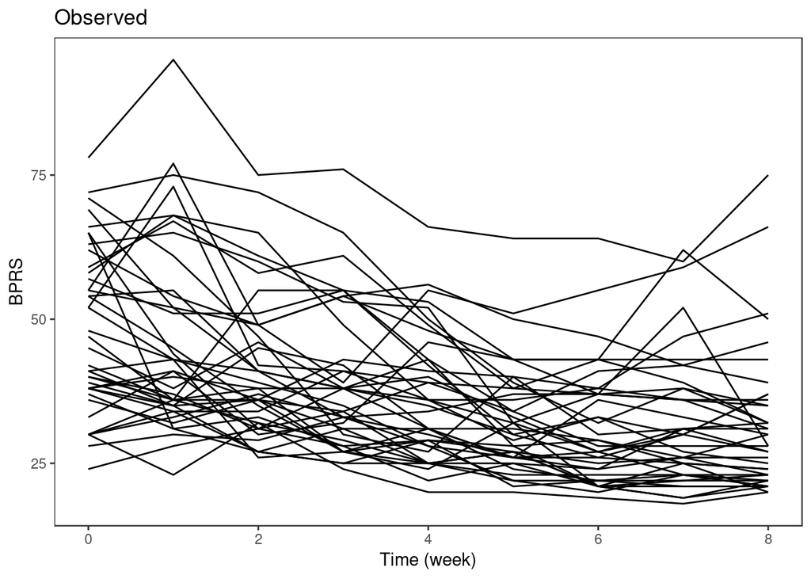

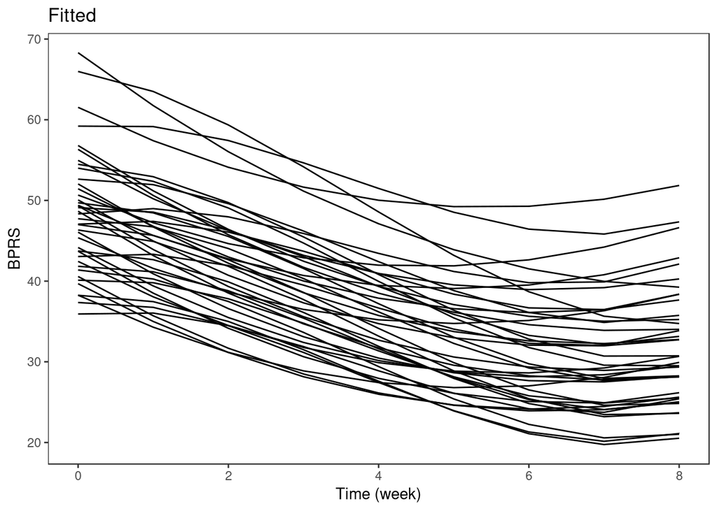

```r
Fitted <- fitted(BPRS_ref3)
BPRSL2 <- BPRSL %>% mutate(Fitted)
p1 <- ggplot(BPRSL2, aes(x = Week, y = bprs, group = interaction(subject, treatment)))
p2 <- p1 + geom_line() #+ geom_line(aes(linetype = Group))
p3 <- p2 + scale_x_continuous(name = "Time (week)")
p4 <- p3 + scale_y_continuous(name = "BPRS")
p5 <- p4 + theme_bw() + theme(legend.position = "right") # "none" in the book
p6 <- p5 + theme(panel.grid.major = element_blank(), panel.grid.minor = element_blank())
p7 <- p6 + ggtitle("Observed")
graph1 <- p7

p1 <- ggplot(BPRSL2, aes(x = Week, y = Fitted, group = interaction(subject, treatment)))
p2 <- p1 + geom_line() #+ geom_line(aes(linetype = Group))
p3 <- p2 + scale_x_continuous(name = "Time (week)")
p4 <- p3 + scale_y_continuous(name = "BPRS")
p5 <- p4 + theme_bw() + theme(legend.position = "right")
p6 <- p5 + theme(panel.grid.major = element_blank(), panel.grid.minor = element_blank())
p7 <- p6 + ggtitle("Fitted")
graph2 <- p7

graph1; graph2
```

=> Profit!